# Reporte Lectura Singular Value Decomposition on GPU using CUDA

Eduardo Hidalgo

May 31, 2018

# Descomposición en Valores Singulares en GPU usando CUDA

## Temas del Paper

- Resúmen e importancia del tema
- Aplicaciones
- Literatura
- Algoritmo SVD
  - Bidiagonalización
  - Bidiagonalización en GPU
  - Diagonalización de una matriz bidiagonal
- SVD ejemplo en CUBLAS
- Resultados
- Conclusiones

## Resúmen e importancia del tema

El computo de programas de uso general en GPU a adquirido gran notoriedad por su bajo costo y alto rendimiento para el procesamiento de datos. En el trabajo se presentan implementaciones de la descomposición en valores singulares (SVD) de una matriz densa en la **GPU** usando el modelo de progrmación **CUDA**. Un decremento de hasta 60 veces en el tiempo de computo se obtienen cuando se compara contra la implementación de *MATLAB* y de hasta 8 veces cuando se compara contra la implementación de *Intel MKL* en una computadora *Intel Dual Core 2.66GHz*

## Aplicaciones

Esta técnica es ampliamente utilizada para:

- Factorizar una matriz rectangular (real o compleja).
- Calcular la pseudoinversa de una matriz
- Resolver sistemas de ecuaciones lineales homogeneos

La **SVD** de una matriz $A$ tiene la siguiente forma:

$$A = U \Sigma V^{T}$$

donde $U$ es una matriz de $m \times m$ ortogonal y es una matriz diagonal $m \times n$ con los elementos de la diagonal mayores o igulaes a cero (ordenados en orden descendente) y el resto de los elementos igual a 0.

Mediante el uso de lenguajes de alto nivel desarrollados para soportar el paradigma de computacion en **GPU** como **CUDA** se puede paralelizar este procdimiento, pues proveen de una intreface de programación similar a la del lenguaje **C**

### Literatura

*Kruger et al* introducen un marco contextual que permite implementar operaciones de algebra lineal en vectores y matrices de tal suerte que explotan las capacidades del computo en paralelo de la GPU.

*Barrachina et al* presentaron varios algoritmos para procesar la solución de un sistema de ecuaciones lineales en *MATLAB* optimizado para el procesamiento en la **GPU**.

*Me et al* han propuesto esfuerzos para paralelizr el procesamiento del algoritmo de la **SVD** en arquitecturas como *FPGA*,*Cell Processors*, *GPU* (estructuras paralelas escalables)

## Algoritmo SVD

La descomposición **SVD** de una matriz $A$ puede procesarse usando el algoritmo *Golub-Reinsch* (Bidiagonalizacion y Diagonalizacion) o el método de *Hestenes*.El primero es usado en el paquete *LAPACK* y consiste en un algoritmo de dos pasos. Donde la matriz es primero reducida a una forma bidiagonal mediante una serie de transformaciones. Posteriormente, la matriz resultante es diagonalizada usando iteraciones dle método QR.

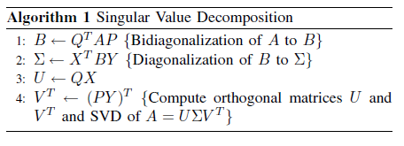

Algoritmo 1: SVD por el método Golub-Reinsch

### Bidiagonalización

Se busca llevar la matriz $A$ al produto de tres matrices:

$$A = QBP^{T}$$

donde $B$ es una matriz bidiagonal y $Q$ y $P$ son matrices unitarias

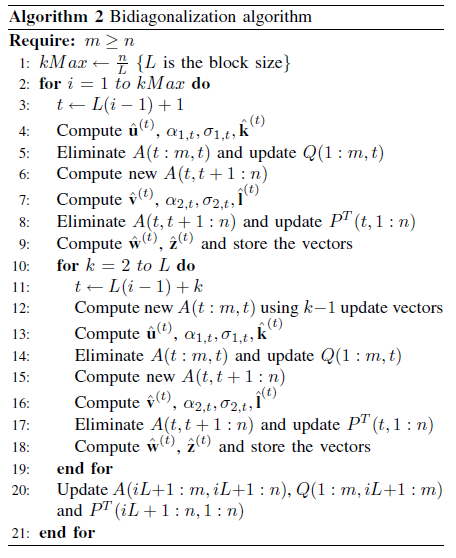

Algoritmo 2: Bidiagonalización

### Diagonalización de una matriz bidiagonal

La matriz bidiagonal obtenida en el paso anterior se reduce a una forma diagonal al aplicar el método inverso del algoritmo QR. La matriz $B$ del paso anterior se descompone como :

$$\Sigma = X^{T}BY$$

donde es una matriz diagonal, $X$ y $Y$ son ortogonales, a continuación se presenta el algoritmo completo:

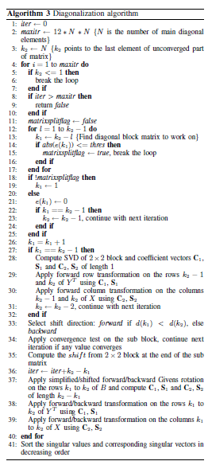

Algoritmo 3: Diagonalización

### Bidiagonalización en GPU

La diagonal y la parte superior de la matriz $B$ son copiadas a la **CPU**. Se aplican las rotaciones en $B$ y se computa el vector de coeficientes de forma secuencial en el CPU dado que sólo requiere acceso a la diagonal y superdiagonal.

[figure not shown]

Todos los *threads* dentro del bloque son usado para copiar los vectores desde la memroia global hacia la memoria compartida.

## SVD ejemplo en CUBLAS

Los autores realizaron una multiplicacion de dos matrices para computar las matrices ortogonales $U = QX \text{ y } V^{T} = (PY)^{T}$ en CUBLAS

## Resultados

En esta sección se analiza el rendimiento del algoritmo optimizado en el CPU versus el algoritmo para la GPU, a continuación se presentan los resultados:

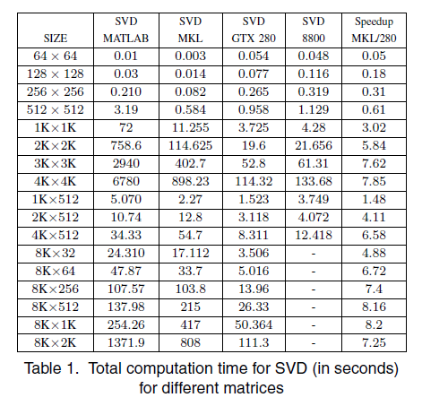

Tabla 1: Comparativo en tiempos de procesamiento

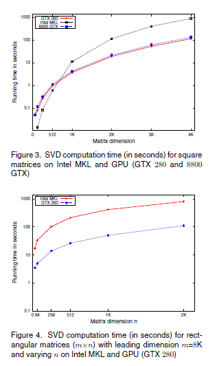

Grafica 1: Comparativo en tiempos de procesamiento